# Steelhead Overshoot Update

4/21/2022

## Simulation study

## Simulation study diagram

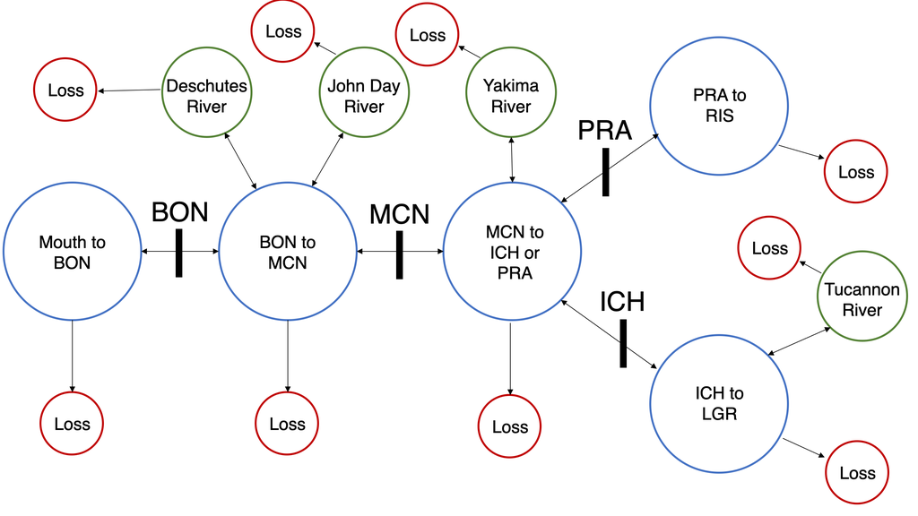

## Covariates included

- Two continuous covariates:
  - Temperature
  - Flow
- Two categorical covariates:
  - Rear type
  - Natal origin

-> generating multiple datasets with different functional relationships between covariates and movement probabilities, including datasets that have no relationship with covariates

## Multinomial logit revisited

### For each movement probability:

Numerator: \[ \begin{aligned} \small \psi_{12}= \exp(\beta_{0,12} + \beta_{temp,12} * temp + \beta_{flow,12} * flow + \\ \beta_{rear,12}[rear] + \beta_{origin,12}[origin]) \\ \end{aligned} \] Denominator: \[ \begin{aligned} 1 + \psi_{12} + \psi_{13} + \psi_{14}... \end{aligned} \] Loss = 1 - \(\Sigma\) (all other movements)

## BON to MCN example

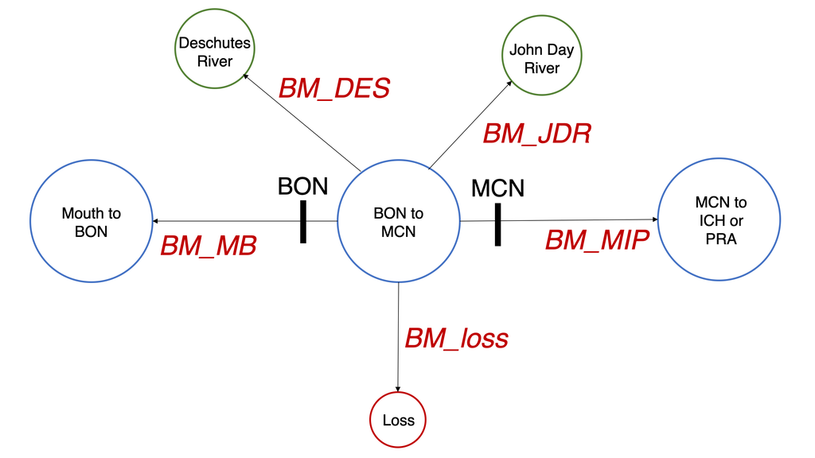

## Multinomial logit revisited

### For each movement probability:

Numerator: \[ \begin{aligned} \small \psi_{BM-JDR}= \exp(\beta_{0,BM-JDR} + \beta_{temp,BM-JDR} * temp + \\ \beta_{flow,BM-JDR} * flow + \beta_{rear,BM-JDR}[rear] + \\ \beta_{origin,BM-JDR}[origin]) \\ \end{aligned} \] Denominator: \[ \begin{aligned} 1 + \psi_{BM-JDR} + \psi_{BM-DES} + \psi_{BM-MIP} + \psi_{BM-MB} \end{aligned} \] *BM-loss* = 1 - \(\Sigma\) (all other movements)

## Behavior of multinomial logit

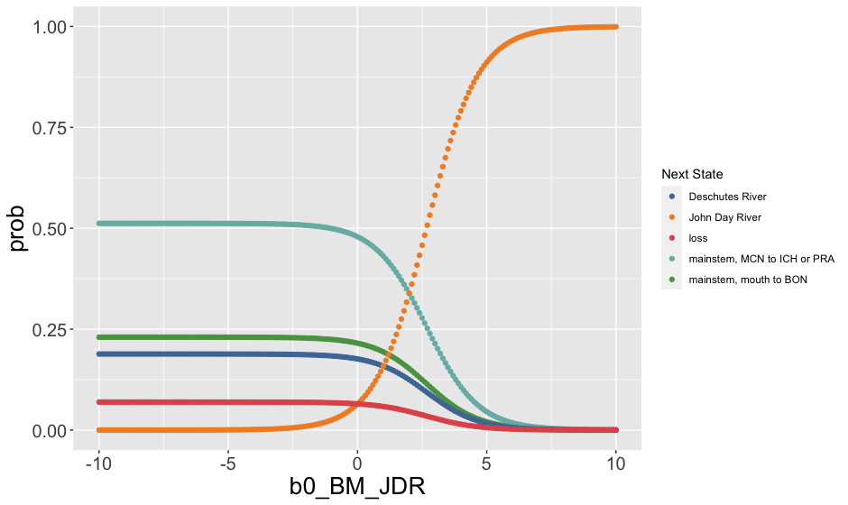

## Simulation code

```r
# (BON to MCN) to (MCN to ICH or PRA) transition
b0_BM_MIP <- 1
bflow_BM_MIP <- 0 # No relationship with flow
btemp_BM_MIP <- 0.5 # When it's hotter, more likely to go upstream
brear_BM_MIP <- c(0,0) # c(hatchery, wild)
borigin_BM_MIP <- c(0.5, 2, 2) # c(JDR, YAK, TUC)
# JDR fish less likely to overshoot MCN

# Evaluate numerator of multinomial logit
phi_BM_MIP <- exp(b0_BM_MIP + btemp_BM_MIP*temp_MCN +
              bflow_BM_MIP*flow_MCN + brear_BM_MIP[rear] +
              borigin_BM_MIP[origin])
```

## Example data

600 simulated detection histories:

```
##                             [,1] [,2] [,3] [,4] [,5]
## mainstem, mouth to BON         0    0    0    0    0
## mainstem, BON to MCN           1    0    1    0    0
## mainstem, MCN to ICH or PRA    0    1    0    0    0
## mainstem, PRA to RIS           0    0    0    0    0
## mainstem, ICH to LGR           0    0    0    0    0
## Deschutes River                0    0    0    0    0
## John Day River                 0    0    0    1    0
## Tucannon River                 0    0    0    0    0
## Yakima River                   0    0    0    0    0
## loss                           0    0    0    0    1
```

## Current approach to JAGS code (which isn’t working yet)

## Using a design matrix

- For each individual state transition, create a matrix \(\mathbf{X}\) that contains 1s (in the case of intercepts, \(\beta_0\), or \(\beta\) values that are not multiplied by a covariate value, e.g., origin and rear type) and covariate values
- Multiply \(\mathbf{X}\) by a vector \(\mathbf{B}\) to get the equation for each \(\psi\)
- Note: There is one \(\mathbf{B}\) vector for each state (total of 9 in our simulated dataset); there is one \(\mathbf{X}\) for each individual transition
  - In the simulated dataset of 600 fish, we have about 3,000 individual trans itions; in the full dataset it’s about 200,000

## Matrix setup

\[ \underbrace{\begin{bmatrix} \psi_{12} \\ \psi_{13} \\ \psi_{14} \\ \psi_{15} \end{bmatrix}}_{\mathbf{\psi}} = \underbrace{\begin{bmatrix} 1 & 0 & 0 & 0 & t_1 & 0 & 0 & 0 \\ 0 & 1 & 0 & 0 & 0 & t_2 & 0 & 0 \\ 0 & 0 & 1 & 0 & 0 & 0 & t_3 & 0 \\ 0 & 0 & 0 & 1 & 0 & 0 & 0 & t_4 \end{bmatrix}}_{\mathbf{X} (\text{data})} \underbrace{\begin{bmatrix} \beta_{0,1} \\ \vdots \\ \beta_{0,4} \\ \beta_{t,1} \\ \vdots \\ \beta_{t,4} \end{bmatrix}}_{\mathbf{B} (\text{JAGS})} \] One row for each possible movement (except loss).

Additional columns are added for each covariate.

## Matrix setup

This gives you a column vector \(\mathbf{\psi}\) which corresponds to the numerators of the each of the movement probabilities except loss.

Exponentiating this \(\mathbf{\psi}\) vector and dividing this vector by the scalar \((1 + \Sigma(exp(\mathbf{\psi}))\) gives you a vector of the non-loss movement probabilities.

\[ \frac{exp(\mathbf{\psi})}{1 + \Sigma(exp(\mathbf{\psi}))} \]

Loss is then 1 - the sum of this vector.

## Evaluating in JAGS

These different movement probabilities are then summarized into a single vector, which can then be evaluated in JAGS using dmulti():

\[ p = c(\frac{exp(\mathbf{\psi})}{1 + \Sigma(exp(\mathbf{\psi}))}, loss) \]

```r
y[,i,j] <- dmulti(p, 1)
```